# 課程: Python程式語言應用專題報告

# 主題: 投資人投資組合-集群法應用

# 學號: 168

# 姓名: 李明昌

# 日期: 2024年10月3日

```python
# 注意:
# 1. 本研究使用 Jupyter notebook 撰寫, 版本如下:
# !jupyter --version
```

```python
# 2. 將 Jupyter notebook 轉換為 py 方法如下:
# !jupyter nbconvert --to script report_168_alan.ipynb
```

```python
# 3. 下載舊版 Anaconda
# 下載最新版 Anaconda: https://www.anaconda.com/download
# 如果 Jupyter notebook 使用時有異常, 可以下載舊版 Anaconda: https://repo.anaconda.com/archive/
# 範例： Anaconda3-2024.02-1-Windows-x86_64.exe, https://repo.anaconda.com/archive/Anaconda3-2024.02-1-Windows-x86_64.exe
```

##### 4.報告規範:

https://github.com/rwepa/python_data_scientist/blob/main/report_readme.txt

# 1.商業理解

```python
# 研究目的: 探討投資人的投資組合集群分析-使用集群法
# 資料來源: Machine Learning and Data Science Blueprints for Finance, 2020.
# 資料名稱: investor_portfolio.csv
# 資料網址: https://github.com/rwepa/DataDemo/blob/master/investor_portfolio.csv
# 報告名稱: report_168_alan.ipynb
```

研究的目標是建立一個機器學習模型，使用非監督式學習的Ｋ-means 集群法。根據人口統計、承擔風險的能力和意願變數對投資人進行集群分析。

# 2.資料理解

## 2.1 資料匯入

```python
# 載入 Python 模組
import numpy as np
import pandas as pd
import matplotlib.pyplot as plt
from pandas import read_csv, set_option
import seaborn as sns

# 載入 scikit-learn 集群法模組
from sklearn import cluster
from sklearn.cluster import KMeans

# 載入計算側影係數
from sklearn import metrics
```

```python
# 載入資料
df = pd.read_csv('investor_portfolio.csv')
```

```python
# 檢視資料
df
```

|  | ID | AGE | EDUC | MARRIED | KIDS | LIFECL | OCCAT | RISK | HHOUSES | WSAVED | SPENDMOR | NWCAT | INCCL |
| --- | --- | --- | --- | --- | --- | --- | --- | --- | --- | --- | --- | --- | --- |
| 0 | 1 | 3 | 2 | 1 | 0 | 2 | 1 | 3 | 1 | 1 | 5 | 3 | 4 |
| 1 | 2 | 4 | 4 | 1 | 2 | 5 | 2 | 3 | 0 | 2 | 5 | 5 | 5 |
| 2 | 3 | 3 | 1 | 1 | 2 | 3 | 2 | 2 | 1 | 2 | 4 | 4 | 4 |
| 3 | 4 | 3 | 1 | 1 | 2 | 3 | 2 | 2 | 1 | 2 | 4 | 3 | 4 |
| 4 | 5 | 4 | 3 | 1 | 1 | 5 | 1 | 2 | 1 | 3 | 3 | 5 | 5 |
| ... | ... | ... | ... | ... | ... | ... | ... | ... | ... | ... | ... | ... | ... |
| 3861 | 3862 | 3 | 1 | 1 | 1 | 3 | 1 | 4 | 0 | 2 | 3 | 1 | 3 |
| 3862 | 3863 | 3 | 1 | 1 | 1 | 3 | 1 | 4 | 0 | 2 | 3 | 1 | 4 |
| 3863 | 3864 | 5 | 1 | 1 | 0 | 5 | 1 | 4 | 0 | 3 | 5 | 1 | 4 |
| 3864 | 3865 | 2 | 4 | 1 | 7 | 3 | 1 | 3 | 1 | 3 | 2 | 5 | 5 |
| 3865 | 3866 | 3 | 4 | 2 | 0 | 1 | 2 | 2 | 1 | 2 | 5 | 4 | 4 |

3866 rows × 13 columns

## 2.2 資料摘要

```python
# 資料物件
type(df)
```

```
pandas.core.frame.DataFrame
```

```python
# 資料型態
df.dtypes # 資料皆為整數
```

```
ID          int64
AGE         int64
EDUC        int64
MARRIED     int64
KIDS        int64
LIFECL      int64
OCCAT       int64
RISK        int64
HHOUSES     int64
WSAVED      int64
SPENDMOR    int64
NWCAT       int64
INCCL       int64
dtype: object
```

```python
# 資料摘要
pd.set_option('display.precision', 2)
df.describe(include='all')
```

|  | ID | AGE | EDUC | MARRIED | KIDS | LIFECL | OCCAT | RISK | HHOUSES | WSAVED | SPENDMOR | NWCAT | INCCL |
| --- | --- | --- | --- | --- | --- | --- | --- | --- | --- | --- | --- | --- | --- |
| count | 3866.00 | 3866.00 | 3866.00 | 3866.00 | 3866.00 | 3866.00 | 3866.00 | 3866.00 | 3866.00 | 3866.00 | 3866.00 | 3866.00 | 3866.00 |
| mean | 1933.50 | 3.11 | 2.91 | 1.35 | 0.94 | 3.70 | 1.74 | 3.04 | 0.72 | 2.45 | 3.56 | 2.98 | 3.67 |
| std | 1116.16 | 1.51 | 1.07 | 0.48 | 1.25 | 1.62 | 0.93 | 0.88 | 0.45 | 0.74 | 1.30 | 1.46 | 1.18 |
| min | 1.00 | 1.00 | 1.00 | 1.00 | 0.00 | 1.00 | 1.00 | 1.00 | 0.00 | 1.00 | 1.00 | 1.00 | 1.00 |
| 25% | 967.25 | 2.00 | 2.00 | 1.00 | 0.00 | 3.00 | 1.00 | 2.00 | 0.00 | 2.00 | 2.00 | 2.00 | 3.00 |
| 50% | 1933.50 | 3.00 | 3.00 | 1.00 | 0.00 | 3.00 | 1.00 | 3.00 | 1.00 | 3.00 | 4.00 | 3.00 | 4.00 |
| 75% | 2899.75 | 4.00 | 4.00 | 2.00 | 2.00 | 5.00 | 3.00 | 4.00 | 1.00 | 3.00 | 5.00 | 4.00 | 5.00 |
| max | 3866.00 | 6.00 | 4.00 | 2.00 | 8.00 | 6.00 | 4.00 | 4.00 | 1.00 | 3.00 | 5.00 | 5.00 | 5.00 |

欄位說明: https://github.com/rwepa/DataDemo/blob/master/README.md#investor_portfoliocsv

三大屬性:

1.人口統計屬性:6個

2.財務屬性:4個

3.行為屬性:2個

欄位名稱:

ID : 編號

AGE : 年齡, 6個類別, 1:35歲以下(不含), 2:35-45, 3:45-55, 4:55-65, 5:65-75, 6:75歲以上(含)【人口統計屬性】

EDUC : 教育程度, 1:高中以下, 4:大學【人口統計屬性】

MARRIED : 是否已婚, 1:已婚, 2:未婚【人口統計屬性】

KIDS : 子女數【人口統計屬性】

LIFECL : 生命週期, 6個類別, 1:35歲以下,未婚,無子女; 6:55歲以上,無工作【人口統計屬性】

OCCAT : 職業(occupation category), 1:管理職, 4:失業【人口統計屬性】

HHOUSES : 自有房屋, 1:有, 0:沒有【財務屬性】

WSAVED : 支出與收入類別, 3個類別, 1:支出>收入, 2:支出=收入, 3:支出<收入【財務屬性】

NWCAT : 淨值類別(net worth category), 5個類別, 1:淨值低於25百分位數, 5:淨值高於90百分位數【財務屬性】

INCCL : 收入類別(income category), 5個類別, 1:收入低於1萬元, 5:收入超過10萬元【財務屬性】

RISK : 願意承受風險的程度, 1:願意承受風險的程度最高, 4:願意承受風險的程度最低【行為屬性】,本屬性可考量為**反應變數**。

SPENDMOR: 支出偏好, 5個類別, 5:最高支出偏好【行為屬性】

# 2.3 探索性資料分析(Exploratory Data Analysis, EDA)

```python
# 資料列數與行數
df.shape # 3866*13
```

```
(3866, 13)
```

```python
# 欄位名稱
df.columns
```

```
Index(['ID', 'AGE', 'EDUC', 'MARRIED', 'KIDS', 'LIFECL', 'OCCAT', 'RISK',
       'HHOUSES', 'WSAVED', 'SPENDMOR', 'NWCAT', 'INCCL'],
      dtype='object')
```

```python
# 檢查NA值
df.isnull().sum() # 所有變數皆沒有NA值
```

```
ID          0
AGE         0
EDUC        0
MARRIED     0
KIDS        0
LIFECL      0
OCCAT       0
RISK        0
HHOUSES     0
WSAVED      0
SPENDMOR    0
NWCAT       0
INCCL       0
dtype: int64
```

```python
# 顯示前5筆
df.head()
```

|  | ID | AGE | EDUC | MARRIED | KIDS | LIFECL | OCCAT | RISK | HHOUSES | WSAVED | SPENDMOR | NWCAT | INCCL |
| --- | --- | --- | --- | --- | --- | --- | --- | --- | --- | --- | --- | --- | --- |
| 0 | 1 | 3 | 2 | 1 | 0 | 2 | 1 | 3 | 1 | 1 | 5 | 3 | 4 |
| 1 | 2 | 4 | 4 | 1 | 2 | 5 | 2 | 3 | 0 | 2 | 5 | 5 | 5 |
| 2 | 3 | 3 | 1 | 1 | 2 | 3 | 2 | 2 | 1 | 2 | 4 | 4 | 4 |
| 3 | 4 | 3 | 1 | 1 | 2 | 3 | 2 | 2 | 1 | 2 | 4 | 3 | 4 |
| 4 | 5 | 4 | 3 | 1 | 1 | 5 | 1 | 2 | 1 | 3 | 3 | 5 | 5 |

```python
# 顯示後5筆
df.tail()
```

|  | ID | AGE | EDUC | MARRIED | KIDS | LIFECL | OCCAT | RISK | HHOUSES | WSAVED | SPENDMOR | NWCAT | INCCL |
| --- | --- | --- | --- | --- | --- | --- | --- | --- | --- | --- | --- | --- | --- |
| 3861 | 3862 | 3 | 1 | 1 | 1 | 3 | 1 | 4 | 0 | 2 | 3 | 1 | 3 |
| 3862 | 3863 | 3 | 1 | 1 | 1 | 3 | 1 | 4 | 0 | 2 | 3 | 1 | 4 |
| 3863 | 3864 | 5 | 1 | 1 | 0 | 5 | 1 | 4 | 0 | 3 | 5 | 1 | 4 |
| 3864 | 3865 | 2 | 4 | 1 | 7 | 3 | 1 | 3 | 1 | 3 | 2 | 5 | 5 |
| 3865 | 3866 | 3 | 4 | 2 | 0 | 1 | 2 | 2 | 1 | 2 | 5 | 4 | 4 |

## 2.4 資料視覺化

```python
# 計算相關係數
mydf = df.drop(['ID'], axis=1) # axis=1 表示行
mydf
```

|  | AGE | EDUC | MARRIED | KIDS | LIFECL | OCCAT | RISK | HHOUSES | WSAVED | SPENDMOR | NWCAT | INCCL |
| --- | --- | --- | --- | --- | --- | --- | --- | --- | --- | --- | --- | --- |
| 0 | 3 | 2 | 1 | 0 | 2 | 1 | 3 | 1 | 1 | 5 | 3 | 4 |
| 1 | 4 | 4 | 1 | 2 | 5 | 2 | 3 | 0 | 2 | 5 | 5 | 5 |
| 2 | 3 | 1 | 1 | 2 | 3 | 2 | 2 | 1 | 2 | 4 | 4 | 4 |
| 3 | 3 | 1 | 1 | 2 | 3 | 2 | 2 | 1 | 2 | 4 | 3 | 4 |
| 4 | 4 | 3 | 1 | 1 | 5 | 1 | 2 | 1 | 3 | 3 | 5 | 5 |
| ... | ... | ... | ... | ... | ... | ... | ... | ... | ... | ... | ... | ... |
| 3861 | 3 | 1 | 1 | 1 | 3 | 1 | 4 | 0 | 2 | 3 | 1 | 3 |
| 3862 | 3 | 1 | 1 | 1 | 3 | 1 | 4 | 0 | 2 | 3 | 1 | 4 |
| 3863 | 5 | 1 | 1 | 0 | 5 | 1 | 4 | 0 | 3 | 5 | 1 | 4 |
| 3864 | 2 | 4 | 1 | 7 | 3 | 1 | 3 | 1 | 3 | 2 | 5 | 5 |
| 3865 | 3 | 4 | 2 | 0 | 1 | 2 | 2 | 1 | 2 | 5 | 4 | 4 |

3866 rows × 12 columns

```python
pd.set_option('display.precision',4)
correlation = mydf.corr()
correlation
```

|  | AGE | EDUC | MARRIED | KIDS | LIFECL | OCCAT | RISK | HHOUSES | WSAVED | SPENDMOR | NWCAT | INCCL |
| --- | --- | --- | --- | --- | --- | --- | --- | --- | --- | --- | --- | --- |
| AGE | 1.0000 | -0.0299 | 0.0438 | -0.3713 | 0.7636 | 0.4127 | 0.0605 | 0.2841 | 0.0014 | 0.1009 | 0.3906 | 0.0561 |
| EDUC | -0.0299 | 1.0000 | -0.0528 | -0.0322 | -0.0844 | -0.1162 | -0.3572 | 0.1622 | 0.1431 | -0.0422 | 0.3819 | 0.4318 |
| MARRIED | 0.0438 | -0.0528 | 1.0000 | -0.2326 | -0.0230 | 0.1193 | 0.1344 | -0.2698 | -0.1064 | 0.0517 | -0.2640 | -0.4144 |
| KIDS | -0.3713 | -0.0322 | -0.2326 | 1.0000 | -0.1168 | -0.1670 | -0.0223 | 0.0035 | -0.0191 | -0.0621 | -0.0464 | 0.0771 |
| LIFECL | 0.7636 | -0.0844 | -0.0230 | -0.1168 | 1.0000 | 0.4213 | 0.0928 | 0.1976 | -0.0328 | 0.0625 | 0.2441 | -0.0174 |
| OCCAT | 0.4127 | -0.1162 | 0.1193 | -0.1670 | 0.4213 | 1.0000 | 0.1070 | 0.0140 | -0.0557 | 0.0536 | 0.1134 | -0.2300 |
| RISK | 0.0605 | -0.3572 | 0.1344 | -0.0223 | 0.0928 | 0.1070 | 1.0000 | -0.1775 | -0.1326 | 0.0787 | -0.3409 | -0.3747 |
| HHOUSES | 0.2841 | 0.1622 | -0.2698 | 0.0035 | 0.1976 | 0.0140 | -0.1775 | 1.0000 | 0.1087 | 0.0409 | 0.5838 | 0.4170 |
| WSAVED | 0.0014 | 0.1431 | -0.1064 | -0.0191 | -0.0328 | -0.0557 | -0.1326 | 0.1087 | 1.0000 | 0.0338 | 0.2239 | 0.2698 |
| SPENDMOR | 0.1009 | -0.0422 | 0.0517 | -0.0621 | 0.0625 | 0.0536 | 0.0787 | 0.0409 | 0.0338 | 1.0000 | -0.0094 | -0.0656 |
| NWCAT | 0.3906 | 0.3819 | -0.2640 | -0.0464 | 0.2441 | 0.1134 | -0.3409 | 0.5838 | 0.2239 | -0.0094 | 1.0000 | 0.6097 |
| INCCL | 0.0561 | 0.4318 | -0.4144 | 0.0771 | -0.0174 | -0.2300 | -0.3747 | 0.4170 | 0.2698 | -0.0656 | 0.6097 | 1.0000 |

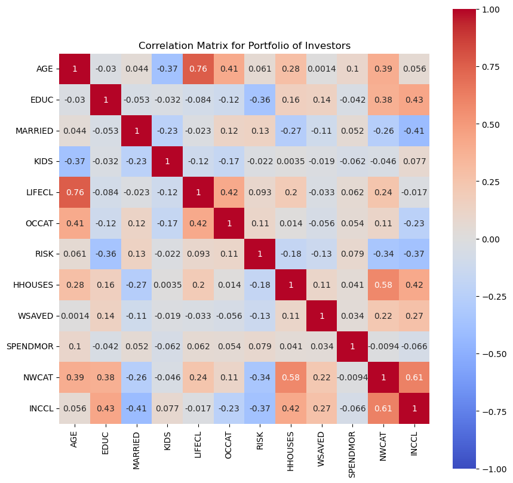

```python
# seaborn galley: https://seaborn.pydata.org/examples/index.html
plt.figure(figsize=(10,10))
plt.title('Correlation Matrix for Portfolio of Investors')
sns.heatmap(correlation, square=True, vmin = -1, vmax = 1, center = 0, annot=True,cmap = 'coolwarm')
```

上方相關係數圖顯示以下之特質: 1.風險承受能力(RISK)與淨值類別(NWCAT)與)呈現負相關。例: RISK為1之願意承受風險的程度最高者，其淨值類別(NWCAT)為較高5。 2.風險承受能力(RISK)與INCCL(收入類別相關)呈現負相關。 3.風險承受能力(RISK)與孩子數目 (KIDS呈現負相關。直觀。

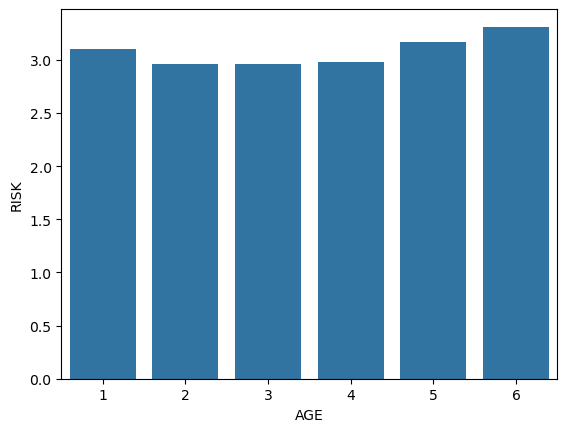

```python
# 平均風險承受能力(RISK)VS年齡(AGE)長條圖
# 結果顯示風險承受能力先下降再提升
mydf = df
mydf["AGE"] = mydf["AGE"].astype("category")
sns.barplot(x='AGE', y='RISK', data=mydf, errorbar=None)
```

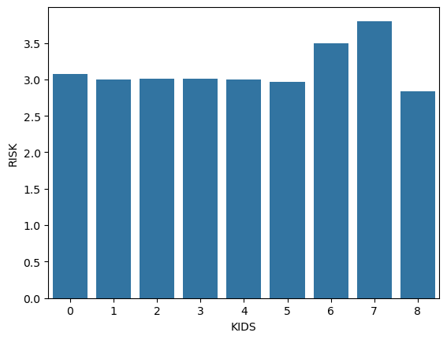

```python
# 平均風險承受能力(RISK)VS子女數(KIDS)長條圖
# 結果顯示子女數(KIDS)約7個時達平均風險承受能力最大值(平均風險承受能力愈低)
mydf["KIDS"] = mydf["KIDS"].astype("category")
sns.barplot(x='KIDS', y='RISK', data=mydf, errorbar=None)
```

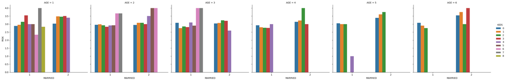

```python
# 說明下圖之結果
mydf["MARRIED"] = mydf["MARRIED"].astype("category")
#sns.catplot(x="MARRIED", y="RISK", hue="KIDS", col="AGE", data=mydf, kind="bar", height=4, aspect=.7, errorbar=None)
sns.catplot(x="MARRIED", y="RISK", hue="KIDS", col="AGE", data=mydf, kind="bar", errorbar=None)
```

# 3.資料準備

資料準備主要工作是將資料隨機區分為二大類：訓練集（train dataset）與測試集（test dataset）為主。 建立型模可以先考慮要使例使用非監督式學習方法，資料暫先不用區分訓練集與測試集。

# 4.建立模型

建立模型方法包括推論統計、機器學習、深度學習與生成式學習等方法。本研究使用非監督式學習 K-means集群法。

```python
# 先刪除沒有使用的ID變數
# 因資料的差異性不大，且具有相似值，因此先不用進行資料轉換
X=df.drop(['ID'], axis=1)
X # 3866 × 12
```

|  | AGE | EDUC | MARRIED | KIDS | LIFECL | OCCAT | RISK | HHOUSES | WSAVED | SPENDMOR | NWCAT | INCCL |
| --- | --- | --- | --- | --- | --- | --- | --- | --- | --- | --- | --- | --- |
| 0 | 3 | 2 | 1 | 0 | 2 | 1 | 3 | 1 | 1 | 5 | 3 | 4 |
| 1 | 4 | 4 | 1 | 2 | 5 | 2 | 3 | 0 | 2 | 5 | 5 | 5 |
| 2 | 3 | 1 | 1 | 2 | 3 | 2 | 2 | 1 | 2 | 4 | 4 | 4 |
| 3 | 3 | 1 | 1 | 2 | 3 | 2 | 2 | 1 | 2 | 4 | 3 | 4 |
| 4 | 4 | 3 | 1 | 1 | 5 | 1 | 2 | 1 | 3 | 3 | 5 | 5 |
| ... | ... | ... | ... | ... | ... | ... | ... | ... | ... | ... | ... | ... |
| 3861 | 3 | 1 | 1 | 1 | 3 | 1 | 4 | 0 | 2 | 3 | 1 | 3 |
| 3862 | 3 | 1 | 1 | 1 | 3 | 1 | 4 | 0 | 2 | 3 | 1 | 4 |
| 3863 | 5 | 1 | 1 | 0 | 5 | 1 | 4 | 0 | 3 | 5 | 1 | 4 |
| 3864 | 2 | 4 | 1 | 7 | 3 | 1 | 3 | 1 | 3 | 2 | 5 | 5 |
| 3865 | 3 | 4 | 2 | 0 | 1 | 2 | 2 | 1 | 2 | 5 | 4 | 4 |

3866 rows × 12 columns

# 4.1 K-means集群法

```python
# K-means 集群法示範

# https://github.com/rwepa/r_data_scientist/blob/main/r_kmeans_animation.gif

# R程式碼: https://github.com/rwepa/r_data_scientist/blob/main/r_kmeans_animation.R
```

評估模型集群個數的方法包括:

1. 陡坡圖（Scree plot）
2. 側影係數（Silhouette coefficient）

# 4.2 方法1 群內距離平方和陡坡圖（Scree plot）

繪製群內距離平方和陡坡圖 (Sum of square errors within clusters, 簡稱 SSE)，降低最明顯之K值為集群數。

群內距離平方和陡坡圖又稱為手肘法（Elbow method）

```python
# 計算群內 SSE
distorsions = []
max_loop=30

for k in range(2, max_loop):
    k_means = KMeans(n_clusters=k)
    k_means.fit(X)
    distorsions.append(k_means.inertia_)

distorsions
```

```
[43571.11802589656,
 37573.44812460114,
 34453.00814540151,
 30591.932011554854,
 29240.93857059658,
 28354.82556578546,
 27403.581446774857,
 25851.62367190421,
 25211.696035379602,
 24249.10321006414,
 23798.744142458094,
 23180.669612245532,
 22662.502475017336,
 22125.19785965468,
 21878.33166261029,
 21400.35199415213,
 20967.939638634867,
 20640.957319814213,
 20219.692037899153,
 19947.35245234775,
 19724.51505016489,
 19556.639260722874,
 19221.14029457558,
 18769.33093021637,
 18917.407669122786,
 18512.29714933016,
 18214.575225852444,
 18078.67271989965]
```

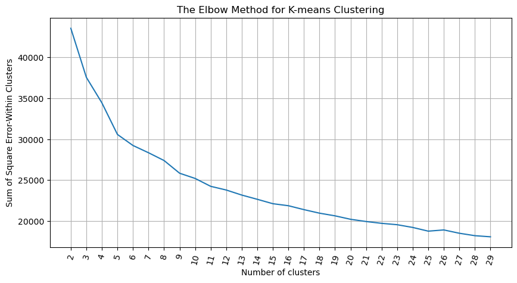

```python
# 群內距離平方和陡坡圖
fig = plt.figure(figsize=(10, 5))
plt.plot(range(2, max_loop), distorsions)
plt.xticks([i for i in range(2, max_loop)], rotation=75)
plt.xlabel("Number of clusters")
plt.ylabel("Sum of Square Error-Within Clusters")
plt.title("The Elbow Method for K-means Clustering")
plt.grid(True)
```

# 4.3 方法2 使用側影係數（Silhouette coefficient）

- 側影係數又稱為輪廓分數（Silhouette Score）。
- 在機器學習與數據挖掘領域，輪廓指的是一種反映數據聚類結果一致性的方法。
- 側影係數衡量一個點與它自己的集群（凝聚力）相比於其他集群（分離）的相似程度。
- 側影係數廓值的範圍在 1 到 –1 之側影係數越高，表示該點越適合在該集群之中。
- 如果側影係數的輪值廓大部分是負值，則可能是建立了太多或太少的集群。

參考https://en.wikipedia.org/wiki/Silhouette_(clustering)

步驟1 計算集群內平均距離 $a(i)$。

步驟2 計算最鄰近集群間平均距離 $b(i)$。

步驟3 計算每個資料點$i$側影係數：

$s(i)={\frac {b(i)-a(i)}{\max\{a(i),b(i)\}}}$

上式可以以改寫為： $s(i)={\begin{cases}1-a(i)/b(i),&{\mbox{if }}a(i)<b(i)\\0,&{\mbox{if }}a(i)=b(i)\\b(i)/a(i)-1,&{\mbox{if }}a(i)>b(i)\\\end{cases}}$ 且 $-1\leq s(i)\leq 1$

```python
# 使用 metrics.silhouette_score 函數計算側影係數
silhouette_score = []
for k in range(2, max_loop):
        kmeans = KMeans(n_clusters=k,  random_state=10, n_init=10)
        kmeans.fit(X)
        silhouette_score.append(metrics.silhouette_score(X, kmeans.labels_, random_state=10))

silhouette_score
```

```
[0.2544089264150241,
 0.20215644186231574,
 0.18520483889712674,
 0.186603624753214,
 0.17517140818856253,
 0.16746166685459618,
 0.16155207527816903,
 0.1551748437010208,
 0.14784508431917154,
 0.15315189978565352,
 0.1436352684912865,
 0.14877494266375477,
 0.13925334511512985,
 0.14021996843343293,
 0.13993697049851966,
 0.13768471192693238,
 0.13906710967733774,
 0.12995709613601597,
 0.1408399034974352,
 0.13336220014342093,
 0.13491820920833048,
 0.13345852780628376,
 0.13065159608112403,
 0.13318099404221184,
 0.1307303614993667,
 0.13243683876201995,
 0.12979897661650927,
 0.13067306278318006]
```

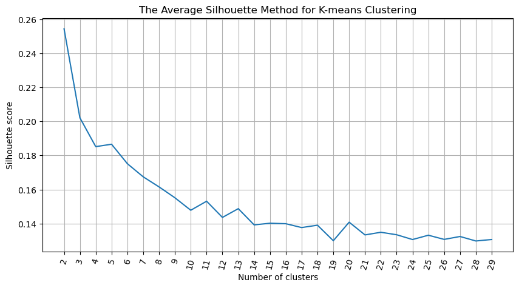

```python
# 側影係數圖
fig = plt.figure(figsize=(10, 5))
plt.plot(range(2, max_loop), silhouette_score)
plt.xticks([i for i in range(2, max_loop)], rotation=75)
plt.xlabel("Number of clusters")
plt.ylabel("Silhouette score")
plt.title("The Average Silhouette Method for K-means Clustering")
plt.grid(True)
```

# 4.4 K-means集群預測

```python
# 設定集群數
nclust=7
```

```python
# 建立 k-means集群法且 K=7
k_means = cluster.KMeans(n_clusters=nclust)
k_means.fit(X)
```

```
KMeans(n_clusters=7)
```

```python
# 預測分群結果, 使用 predict 函數
target_labels = k_means.predict(X)
target_labels
```

```
array([5, 1, 2, ..., 3, 2, 2])
```

# 5.評估與測試

```python
# K-means集群—評估
print("km", metrics.silhouette_score(X, k_means.labels_, metric='euclidean'))
```

```
km 0.16268933856065337
```

# 6.佈署應用與結論

```python
# 將變數轉換為原來整數, 本例使用 int64.
X["MARRIED"] = X["MARRIED"].astype("int64")
X["KIDS"] = X["KIDS"].astype("int64")
X["AGE"] = X["AGE"].astype("int64")
X.dtypes
```

```
AGE         int64
EDUC        int64
MARRIED     int64
KIDS        int64
LIFECL      int64
OCCAT       int64
RISK        int64
HHOUSES     int64
WSAVED      int64
SPENDMOR    int64
NWCAT       int64
INCCL       int64
dtype: object
```

```python
# 繪製各集群重要變數的長條圖
cluster_output= pd.concat([pd.DataFrame(X), pd.DataFrame(k_means.labels_, columns = ['cluster'])],axis = 1)
cluster_output
```

|  | AGE | EDUC | MARRIED | KIDS | LIFECL | OCCAT | RISK | HHOUSES | WSAVED | SPENDMOR | NWCAT | INCCL | cluster |
| --- | --- | --- | --- | --- | --- | --- | --- | --- | --- | --- | --- | --- | --- |
| 0 | 3 | 2 | 1 | 0 | 2 | 1 | 3 | 1 | 1 | 5 | 3 | 4 | 5 |
| 1 | 4 | 4 | 1 | 2 | 5 | 2 | 3 | 0 | 2 | 5 | 5 | 5 | 1 |
| 2 | 3 | 1 | 1 | 2 | 3 | 2 | 2 | 1 | 2 | 4 | 4 | 4 | 2 |
| 3 | 3 | 1 | 1 | 2 | 3 | 2 | 2 | 1 | 2 | 4 | 3 | 4 | 0 |
| 4 | 4 | 3 | 1 | 1 | 5 | 1 | 2 | 1 | 3 | 3 | 5 | 5 | 4 |
| ... | ... | ... | ... | ... | ... | ... | ... | ... | ... | ... | ... | ... | ... |
| 3861 | 3 | 1 | 1 | 1 | 3 | 1 | 4 | 0 | 2 | 3 | 1 | 3 | 6 |
| 3862 | 3 | 1 | 1 | 1 | 3 | 1 | 4 | 0 | 2 | 3 | 1 | 4 | 6 |
| 3863 | 5 | 1 | 1 | 0 | 5 | 1 | 4 | 0 | 3 | 5 | 1 | 4 | 3 |
| 3864 | 2 | 4 | 1 | 7 | 3 | 1 | 3 | 1 | 3 | 2 | 5 | 5 | 2 |
| 3865 | 3 | 4 | 2 | 0 | 1 | 2 | 2 | 1 | 2 | 5 | 4 | 4 | 2 |

3866 rows × 13 columns

```python
# 計算7個集群之變數平均值
output=cluster_output.groupby('cluster').mean()
output
```

| cluster | AGE | EDUC | MARRIED | KIDS | LIFECL | OCCAT | RISK | HHOUSES | WSAVED | SPENDMOR | NWCAT | INCCL |
| --- | --- | --- | --- | --- | --- | --- | --- | --- | --- | --- | --- | --- |
| 0 | 1.9106 | 2.4674 | 1.3147 | 2.1285 | 3.3371 | 1.4283 | 3.3613 | 0.5326 | 2.2570 | 4.5214 | 1.7654 | 3.1695 |
| 1 | 4.6559 | 3.3498 | 1.2452 | 0.3156 | 5.3460 | 2.0475 | 2.8574 | 0.9468 | 2.6350 | 4.5380 | 4.3669 | 4.3308 |
| 2 | 2.4529 | 3.5394 | 1.1342 | 1.5652 | 2.7406 | 1.4439 | 2.4787 | 0.9432 | 2.7110 | 3.5123 | 4.2516 | 4.7174 |
| 3 | 4.8821 | 2.0701 | 1.5949 | 0.1846 | 5.6598 | 2.4410 | 3.5846 | 0.6821 | 2.2325 | 3.9316 | 2.2581 | 2.5846 |
| 4 | 4.5995 | 3.4877 | 1.2452 | 0.3678 | 5.3243 | 2.0463 | 2.7166 | 0.9319 | 2.5695 | 2.0845 | 4.4114 | 4.5068 |
| 5 | 1.9663 | 2.8972 | 1.6166 | 0.0015 | 1.3850 | 1.5169 | 3.1457 | 0.4601 | 2.4064 | 3.5598 | 1.9448 | 3.1074 |
| 6 | 1.9127 | 2.4198 | 1.2925 | 2.0259 | 3.2925 | 1.4198 | 3.2783 | 0.5047 | 2.2146 | 1.9906 | 1.7877 | 3.2217 |

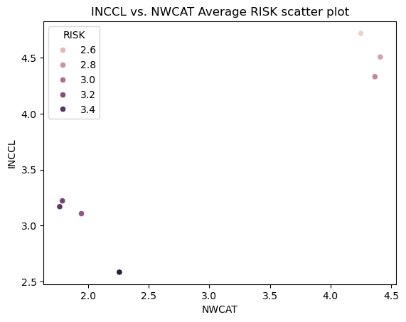

```python
# 繪製集群散佈圖
ax = sns.scatterplot(data=output, x="NWCAT", y="INCCL", hue="RISK")
ax.set_title('INCCL vs. NWCAT Average RISK scatter plot')

# 結果顯示不同 RISK 的散佈圖。
```

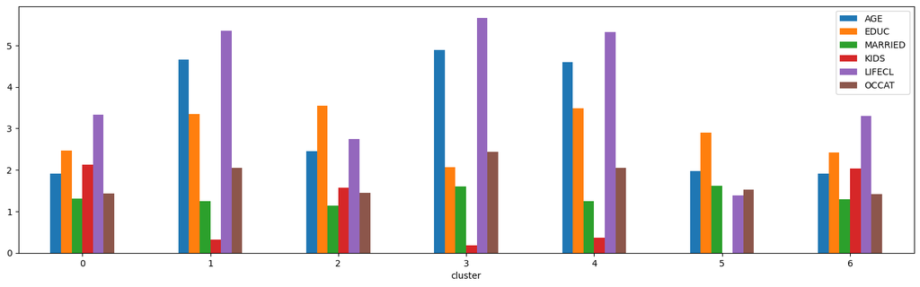

```python
# 依據人口統計特徵(6個變數)繪製長條圖
output[['AGE','EDUC','MARRIED','KIDS','LIFECL','OCCAT']].plot.bar(rot=0, figsize=(18,5))
```

```python
# end
```